# ASSESSMENT1-S4665076

Stephen setiadi s4665076

2022-03-18

# ASSESSMENT1 PART 1

1. Setup your Assessment 1 project:
2. Create the heading of the first level and call it RMarkdown editing

## *RMarkdown Editing*

3. Write 2-3 sentences about RMarkdown (you can google this information or use resources recommended in class - no need to reference)

*R Markdown documents provide quick, reproducible reporting from R. You write your document in markdown and embed executable R code chunks with the knitr syntax. You can update your document at any time by re-knitting the code chunks. You can then convert your document into several common formatting syntax for authoring HTML,PDF and MS Word documents.*

4. In the above use bold and italics for editing.
5. Review the suggested documentation on how to insert links in the .rmd file and include an in-text link to

`https://rmarkdown.rstudio.com/lesson-8.html`

*LINKS* To insert link in the .rmd file you can follow the step of use a plain http address and type the link on the script

`http://example.com` or you can add the link to a phrase*

`[linked phrase](http://example.com)`

for more infomation you can access the link from rstudio by clicking the link [here](https://rmarkdown.rstudio.com/lesson-8.html)

6. Insert an R chunk and create a variable with this dataset

```r
#install.packages("tidyverse")
```

```r
library(tidyverse)
Fast_food <- read.csv("https://raw.githubusercontent.com/rfordatascience/tidytuesday/master/data/2018/2018-09-04/fastfood_calories.csv")
```

7. Display the first 10 rows of the dataset using head() and kable(). Display the first 10 rows of the dataset and the first 5 variables Use Help and the link below to read more about those functions `https://bookdown.org/yihui/rmarkdown-cookbook/kable.html`

```r
head (Fast_food[1:10,])
```

```
##   X restaurant                                      item calories cal_fat
## 1 1  Mcdonalds          Artisan Grilled Chicken Sandwich      380      60
## 2 2  Mcdonalds            Single Bacon Smokehouse Burger      840     410
## 3 3  Mcdonalds            Double Bacon Smokehouse Burger     1130     600
## 4 4  Mcdonalds Grilled Bacon Smokehouse Chicken Sandwich      750     280
## 5 5  Mcdonalds  Crispy Bacon Smokehouse Chicken Sandwich      920     410
## 6 6  Mcdonalds                                   Big Mac      540     250
##   total_fat sat_fat trans_fat cholesterol sodium total_carb fiber sugar protein
## 1         7       2       0.0          95   1110         44     3    11      37
## 2        45      17       1.5         130   1580         62     2    18      46
## 3        67      27       3.0         220   1920         63     3    18      70
## 4        31      10       0.5         155   1940         62     2    18      55
## 5        45      12       0.5         120   1980         81     4    18      46
## 6        28      10       1.0          80    950         46     3     9      25
##   vit_a vit_c calcium salad
## 1     4    20      20 Other
## 2     6    20      20 Other
## 3    10    20      50 Other
## 4     6    25      20 Other
## 5     6    20      20 Other
## 6    10     2      15 Other
```

```r
head (Fast_food[1:10,1:5])
```

```
##   X restaurant                                      item calories cal_fat
## 1 1  Mcdonalds          Artisan Grilled Chicken Sandwich      380      60
## 2 2  Mcdonalds            Single Bacon Smokehouse Burger      840     410
## 3 3  Mcdonalds            Double Bacon Smokehouse Burger     1130     600
## 4 4  Mcdonalds Grilled Bacon Smokehouse Chicken Sandwich      750     280
## 5 5  Mcdonalds  Crispy Bacon Smokehouse Chicken Sandwich      920     410
## 6 6  Mcdonalds                                   Big Mac      540     250
```

```r
#install.packages("kableExtra")
```

```r
library("kableExtra")
knitr::kable(head(Fast_food[1:10,]), "pipe")
```

| X | restaurant | item | calories | cal_fat | total_fat | sat_fat | trans_fat | cholesterol | sodium | total_carb | fiber | sugar | protein | vit_a | vit_c | calcium | salad |
| --- | --- | --- | --- | --- | --- | --- | --- | --- | --- | --- | --- | --- | --- | --- | --- | --- | --- |
| 1 | Mcdonalds | Artisan Grilled Chicken Sandwich | 380 | 60 | 7 | 2 | 0.0 | 95 | 1110 | 44 | 3 | 11 | 37 | 4 | 20 | 20 | Other |
| 2 | Mcdonalds | Single Bacon Smokehouse Burger | 840 | 410 | 45 | 17 | 1.5 | 130 | 1580 | 62 | 2 | 18 | 46 | 6 | 20 | 20 | Other |
| 3 | Mcdonalds | Double Bacon Smokehouse Burger | 1130 | 600 | 67 | 27 | 3.0 | 220 | 1920 | 63 | 3 | 18 | 70 | 10 | 20 | 50 | Other |
| 4 | Mcdonalds | Grilled Bacon Smokehouse Chicken Sandwich | 750 | 280 | 31 | 10 | 0.5 | 155 | 1940 | 62 | 2 | 18 | 55 | 6 | 25 | 20 | Other |
| 5 | Mcdonalds | Crispy Bacon Smokehouse Chicken Sandwich | 920 | 410 | 45 | 12 | 0.5 | 120 | 1980 | 81 | 4 | 18 | 46 | 6 | 20 | 20 | Other |
| 6 | Mcdonalds | Big Mac | 540 | 250 | 28 | 10 | 1.0 | 80 | 950 | 46 | 3 | 9 | 25 | 10 | 2 | 15 | Other |

```r
knitr::kable(head(Fast_food[1:10, 1:5]), "pipe")
```

| X | restaurant | item | calories | cal_fat |
| --- | --- | --- | --- | --- |
| 1 | Mcdonalds | Artisan Grilled Chicken Sandwich | 380 | 60 |
| 2 | Mcdonalds | Single Bacon Smokehouse Burger | 840 | 410 |
| 3 | Mcdonalds | Double Bacon Smokehouse Burger | 1130 | 600 |
| 4 | Mcdonalds | Grilled Bacon Smokehouse Chicken Sandwich | 750 | 280 |
| 5 | Mcdonalds | Crispy Bacon Smokehouse Chicken Sandwich | 920 | 410 |
| 6 | Mcdonalds | Big Mac | 540 | 250 |

# ASSESSMENT1 PART 2

```r
library(knitr)
```

```r
library(skimr)
```

```r
library(kableExtra)
```

```r
Fast_food %>%
  filter(calories >= 1000) %>%
  head(n = 20) %>%
  kable("pipe")
```

| X | restaurant | item | calories | cal_fat | total_fat | sat_fat | trans_fat | cholesterol | sodium | total_carb | fiber | sugar | protein | vit_a | vit_c | calcium | salad |
| --- | --- | --- | --- | --- | --- | --- | --- | --- | --- | --- | --- | --- | --- | --- | --- | --- | --- |
| 3 | Mcdonalds | Double Bacon Smokehouse Burger | 1130 | 600 | 67 | 27 | 3.0 | 220 | 1920 | 63 | 3 | 18 | 70 | 10 | 20 | 50 | Other |
| 38 | Mcdonalds | 10 piece Buttermilk Crispy Chicken Tenders | 1210 | 630 | 70 | 12 | 1.0 | 240 | 3230 | 52 | 1 | 4 | 94 | 0 | 0 | 4 | Other |
| 39 | Mcdonalds | 12 piece Buttermilk Crispy Chicken Tenders | 1510 | 790 | 88 | 15 | 1.0 | 295 | 3770 | 64 | 1 | 2 | 115 | 0 | 2 | 6 | Other |
| 40 | Mcdonalds | 20 piece Buttermilk Crispy Chicken Tenders | 2430 | 1270 | 141 | 24 | 2.0 | 475 | 6080 | 103 | 2 | 3 | 186 | 0 | 2 | 8 | Other |
| 45 | Mcdonalds | 40 piece Chicken McNuggets | 1770 | 960 | 107 | 18 | 0.5 | 295 | 3370 | 105 | 7 | 1 | 98 | 0 | 15 | 6 | Other |
| 48 | Mcdonalds | 10 piece Sweet N’ Spicy Honey BBQ Glazed Tenders | 1600 | 600 | 66 | 10 | 0.0 | 265 | 4450 | 156 | 5 | 87 | 97 | 8 | 40 | 10 | Other |
| 99 | Sonic | Super Sonic Bacon Double Cheeseburger (w/mayo) | 1280 | 830 | 92 | 36 | 4.0 | 260 | 1630 | 44 | 2 | 7 | 67 | 15 | 6 | 40 | Other |
| 100 | Sonic | Super Sonic Double Cheeseburger W/ Mustard | 1120 | 680 | 76 | 32 | 4.0 | 235 | 1550 | 44 | 2 | 8 | 63 | 15 | 8 | 40 | Other |
| 101 | Sonic | Super Sonic Double Cheeseburger W/ Ketchup | 1130 | 680 | 76 | 32 | 4.0 | 235 | 1620 | 47 | 2 | 11 | 63 | 20 | 10 | 40 | Other |
| 102 | Sonic | Super Sonic Double Cheeseburger W/ Mayo | 1220 | 780 | 87 | 34 | 4.0 | 245 | 1520 | 45 | 2 | 8 | 63 | 15 | 8 | 40 | Other |
| 103 | Sonic | Super Sonic Jalapeno Double Cheeseburger | 1120 | 680 | 76 | 32 | 4.0 | 235 | 1690 | 43 | 2 | 7 | 63 | 15 | 2 | 40 | Other |
| 115 | Sonic | Buffalo Dunked Ultimate Chicken Sandwich | 1000 | 550 | 61 | 12 | 0.5 | 125 | 4520 | 70 | 5 | 12 | 23 | NA | NA | NA | Other |
| 116 | Sonic | Garlic Parmesan Dunked Ultimate Chicken Sandwich | 1350 | 900 | 100 | 17 | 0.0 | 190 | 2180 | 69 | 4 | 10 | 23 | NA | NA | NA | Other |
| 122 | Sonic | 4 Piece Super Crunch Chicken Strip Dinner | 1080 | 460 | 51 | 9 | 1.0 | 75 | 2390 | 118 | 8 | 9 | 37 | 1 | 7 | 13 | Other |
| 123 | Sonic | 5 Piece Super Crunch Chicken Strip Dinner | 1190 | 510 | 57 | 10 | 1.0 | 90 | 2610 | 126 | 8 | 9 | 44 | 2 | 8 | 14 | Other |
| 176 | Arbys | Triple Decker Sandwich | 1030 | 459 | 51 | 17 | 1.0 | 155 | 2940 | 83 | 5 | 19 | 62 | NA | NA | NA | Other |
| 193 | Burger King | American Brewhouse King | 1550 | 1134 | 126 | 47 | 8.0 | 805 | 1820 | 21 | 3 | 7 | 134 | NA | NA | NA | Other |
| 194 | Burger King | Bacon & Swiss Sourdough King | 1000 | 585 | 65 | 24 | 3.0 | 200 | 1320 | 48 | 2 | 8 | 56 | NA | NA | NA | Other |
| 197 | Burger King | Bacon King | 1040 | 630 | 48 | 28 | 2.5 | 220 | 1900 | 48 | 1 | 10 | 57 | NA | NA | NA | Other |
| 199 | Burger King | BBQ Bacon King | 1100 | 675 | 75 | 29 | 3.0 | 220 | 1850 | 51 | NA | 13 | 57 | NA | NA | NA | Other |

9. Arrange observations with more than 40 in total_fat and more than 80 in total_carb in the descending order and save them to a new variable (dataset) called `dont_eat_this`

```r
dont_eat_this <- Fast_food %>%
  filter(total_fat>40, total_carb>80)%>%
  select(restaurant, total_fat, total_carb)
```

```r
  arrange(dont_eat_this, desc(total_fat), desc(total_carb))
```

```
##     restaurant total_fat total_carb
## 1    Mcdonalds       141        103
## 2    Mcdonalds       107        105
## 3    Mcdonalds        66        156
## 4  Dairy Queen        66        121
## 5       Subway        62         94
## 6       Subway        58         94
## 7        Sonic        57        126
## 8       Subway        56         94
## 9  Dairy Queen        53        105
## 10      Subway        52         92
## 11       Sonic        51        118
## 12       Arbys        51         83
## 13 Dairy Queen        48         95
## 14      Subway        48         94
## 15      Subway        48         92
## 16      Subway        48         88
## 17       Sonic        46        109
## 18   Mcdonalds        45         81
## 19       Arbys        44         81
## 20   Taco Bell        42         94
```

10. Using the initial dataset variable, use `case_when()` to create a new variable `heavy_food` which is equal to “heavy” when total calories are greater than 500, “low” when total calories are less than 250 and “average” for all other cases. Count the number of observations in each created category.

```r
Fast_food<-Fast_food %>%
  mutate(heavy_food =
           case_when(calories > 500 ~ 'heavy',
                     calories <250 ~ 'low',
                     TRUE ~ 'average'))
```

```r
Fast_food %>%
  count(heavy_food, sort = TRUE, name = 'Calories category')
```

```
##   heavy_food Calories category
## 1      heavy               246
## 2    average               201
## 3        low                68
```

11. Display the types of variables in the dataset using `skimr` package

```r
library(skimr)
```

```r
skim(Fast_food)
```

Data summary

| Name | Fast_food |
| --- | --- |
| Number of rows | 515 |
| Number of columns | 19 |
| _______________________ |  |
| Column type frequency: |  |
| character | 4 |
| numeric | 15 |
| ________________________ |  |
| Group variables | None |

**Variable type: character**

| skim_variable | n_missing | complete_rate | min | max | empty | n_unique | whitespace |
| --- | --- | --- | --- | --- | --- | --- | --- |
| restaurant | 0 | 1 | 5 | 11 | 0 | 8 | 0 |
| item | 0 | 1 | 5 | 63 | 0 | 505 | 0 |
| salad | 0 | 1 | 5 | 5 | 0 | 1 | 0 |
| heavy_food | 0 | 1 | 3 | 7 | 0 | 3 | 0 |

**Variable type: numeric**

| skim_variable | n_missing | complete_rate | mean | sd | p0 | p25 | p50 | p75 | p100 | hist |
| --- | --- | --- | --- | --- | --- | --- | --- | --- | --- | --- |
| X | 0 | 1.00 | 258.00 | 148.81 | 1 | 129.5 | 258.0 | 386.5 | 515 | ▇▇▇▇▇ |
| calories | 0 | 1.00 | 530.91 | 282.44 | 20 | 330.0 | 490.0 | 690.0 | 2430 | ▇▆▁▁▁ |
| cal_fat | 0 | 1.00 | 238.81 | 166.41 | 0 | 120.0 | 210.0 | 310.0 | 1270 | ▇▃▁▁▁ |
| total_fat | 0 | 1.00 | 26.59 | 18.41 | 0 | 14.0 | 23.0 | 35.0 | 141 | ▇▃▁▁▁ |
| sat_fat | 0 | 1.00 | 8.15 | 6.42 | 0 | 4.0 | 7.0 | 11.0 | 47 | ▇▃▁▁▁ |
| trans_fat | 0 | 1.00 | 0.47 | 0.84 | 0 | 0.0 | 0.0 | 1.0 | 8 | ▇▁▁▁▁ |
| cholesterol | 0 | 1.00 | 72.46 | 63.16 | 0 | 35.0 | 60.0 | 95.0 | 805 | ▇▁▁▁▁ |
| sodium | 0 | 1.00 | 1246.74 | 689.95 | 15 | 800.0 | 1110.0 | 1550.0 | 6080 | ▇▆▁▁▁ |
| total_carb | 0 | 1.00 | 45.66 | 24.88 | 0 | 28.5 | 44.0 | 57.0 | 156 | ▅▇▂▁▁ |
| fiber | 12 | 0.98 | 4.14 | 3.04 | 0 | 2.0 | 3.0 | 5.0 | 17 | ▇▅▂▁▁ |
| sugar | 0 | 1.00 | 7.26 | 6.76 | 0 | 3.0 | 6.0 | 9.0 | 87 | ▇▁▁▁▁ |
| protein | 1 | 1.00 | 27.89 | 17.68 | 1 | 16.0 | 24.5 | 36.0 | 186 | ▇▂▁▁▁ |
| vit_a | 214 | 0.58 | 18.86 | 31.38 | 0 | 4.0 | 10.0 | 20.0 | 180 | ▇▁▁▁▁ |
| vit_c | 210 | 0.59 | 20.17 | 30.59 | 0 | 4.0 | 10.0 | 30.0 | 400 | ▇▁▁▁▁ |
| calcium | 210 | 0.59 | 24.85 | 25.52 | 0 | 8.0 | 20.0 | 30.0 | 290 | ▇▁▁▁▁ |

```r
summary(Fast_food)
```

```
##        X          restaurant            item              calories
##  Min.   :  1.0   Length:515         Length:515         Min.   :  20.0
##  1st Qu.:129.5   Class :character   Class :character   1st Qu.: 330.0
##  Median :258.0   Mode  :character   Mode  :character   Median : 490.0
##  Mean   :258.0                                         Mean   : 530.9
##  3rd Qu.:386.5                                         3rd Qu.: 690.0
##  Max.   :515.0                                         Max.   :2430.0
##
##     cal_fat         total_fat         sat_fat         trans_fat
##  Min.   :   0.0   Min.   :  0.00   Min.   : 0.000   Min.   :0.000
##  1st Qu.: 120.0   1st Qu.: 14.00   1st Qu.: 4.000   1st Qu.:0.000
##  Median : 210.0   Median : 23.00   Median : 7.000   Median :0.000
##  Mean   : 238.8   Mean   : 26.59   Mean   : 8.153   Mean   :0.465
##  3rd Qu.: 310.0   3rd Qu.: 35.00   3rd Qu.:11.000   3rd Qu.:1.000
##  Max.   :1270.0   Max.   :141.00   Max.   :47.000   Max.   :8.000
##
##   cholesterol         sodium       total_carb         fiber
##  Min.   :  0.00   Min.   :  15   Min.   :  0.00   Min.   : 0.000
##  1st Qu.: 35.00   1st Qu.: 800   1st Qu.: 28.50   1st Qu.: 2.000
##  Median : 60.00   Median :1110   Median : 44.00   Median : 3.000
##  Mean   : 72.46   Mean   :1247   Mean   : 45.66   Mean   : 4.137
##  3rd Qu.: 95.00   3rd Qu.:1550   3rd Qu.: 57.00   3rd Qu.: 5.000
##  Max.   :805.00   Max.   :6080   Max.   :156.00   Max.   :17.000
##                                                   NA's   :12
##      sugar           protein           vit_a            vit_c
##  Min.   : 0.000   Min.   :  1.00   Min.   :  0.00   Min.   :  0.00
##  1st Qu.: 3.000   1st Qu.: 16.00   1st Qu.:  4.00   1st Qu.:  4.00
##  Median : 6.000   Median : 24.50   Median : 10.00   Median : 10.00
##  Mean   : 7.262   Mean   : 27.89   Mean   : 18.86   Mean   : 20.17
##  3rd Qu.: 9.000   3rd Qu.: 36.00   3rd Qu.: 20.00   3rd Qu.: 30.00
##  Max.   :87.000   Max.   :186.00   Max.   :180.00   Max.   :400.00
##                   NA's   :1        NA's   :214      NA's   :210
##     calcium          salad            heavy_food
##  Min.   :  0.00   Length:515         Length:515
##  1st Qu.:  8.00   Class :character   Class :character
##  Median : 20.00   Mode  :character   Mode  :character
##  Mean   : 24.85
##  3rd Qu.: 30.00
##  Max.   :290.00
##  NA's   :210
```

12. Present the count observations from each restaurant in a descending order. Show the number of distinct items on a menu in the dataset

```r
Fast_food%>%
  count(restaurant, sort = TRUE)%>%
  kable()
```

| restaurant | n |
| --- | --- |
| Taco Bell | 115 |
| Subway | 96 |
| Burger King | 70 |
| Mcdonalds | 57 |
| Arbys | 55 |
| Sonic | 53 |
| Dairy Queen | 42 |
| Chick Fil-A | 27 |

```r
Fast_food%>%
  count(item, sort = TRUE )%>%
  head(n = 20) %>%
  kable()
```

| item | n |
| --- | --- |
| Crispy Chicken Sandwich | 3 |
| Grilled Chicken Sandwich | 3 |
| Cheeseburger | 2 |
| Chili Cheese Burrito | 2 |
| Corn Dog | 2 |
| Double Cheeseburger | 2 |
| Express Taco Salad w/ Chips | 2 |
| Hamburger | 2 |
| 1 Piece Chick-n-Strips | 1 |
| 1/2 lb. FlameThrowerÂ® GrillBurger | 1 |
| 1/2 lb. GrillBurger with Cheese | 1 |
| 1/2 lb.* Cheesy Potato Burrito | 1 |
| 1/2 lb.* Combo Burrito | 1 |
| 1/4 lb. Bacon Cheese GrillBurger | 1 |
| 1/4 lb. GrillBurger with Cheese | 1 |
| 1/4 lb. Mushroom Swiss GrillBurger | 1 |
| 10 piece Buttermilk Crispy Chicken Tenders | 1 |
| 10 Piece Chicken McNuggets | 1 |
| 10 piece Sweet N’ Spicy Honey BBQ Glazed Tenders | 1 |
| 12 piece Buttermilk Crispy Chicken Tenders | 1 |

13. Using groupings (group_by()), summarise and display the average number of calories for each restaurant.

```r
Fast_food%>%
  group_by(restaurant)%>%
  summarise(avg_calories=mean(calories))
```

```
## # A tibble: 8 x 2
##   restaurant  avg_calories
##   <chr>              <dbl>
## 1 Arbys               533.
## 2 Burger King         609.
## 3 Chick Fil-A         384.
## 4 Dairy Queen         520.
## 5 Mcdonalds           640.
## 6 Sonic               632.
## 7 Subway              503.
## 8 Taco Bell           444.
```

14. Add variables to the dataset, which:
- calculates the average calories per type of restaurant and call it `average_calories`

```r
Average_calories<-Fast_food%>%
  group_by(restaurant)%>%
  summarise(ave_cal= mean(calories))
```

```r
Fast_food<-Fast_food%>%
  group_by(restaurant)%>%
  mutate(ave_cal= mean(calories))
```

- calculates the maximum total_fat per type of restaurant and call it `max_fat`

```r
Max_fat<-Fast_food%>%
  group_by(restaurant)%>%
  summarise(max_fat= max(total_fat))
```

```r
Fast_food<-Fast_food%>%
  group_by(restaurant)%>%
  mutate(max_fat= max(total_fat))
```

- calculates the minimum cholesterol per type of restaurant and call it `min_cholesterol`

```r
Min_cho<-Fast_food%>%
  group_by(restaurant)%>%
  summarise(min_cho =min(cholesterol))
```

```r
Fast_food<-Fast_food%>%
  group_by(restaurant)%>%
  mutate(min_cho =min(cholesterol))
```

15. Display the data vis of total fat per each type of restaurant. Write a narration (2-3 sentences) why you believe this type of data viz presents such information best.

```r
Total_fat_rest <- Fast_food%>%
  group_by(restaurant)%>%
  summarise(Total_fat= sum(total_fat))
```

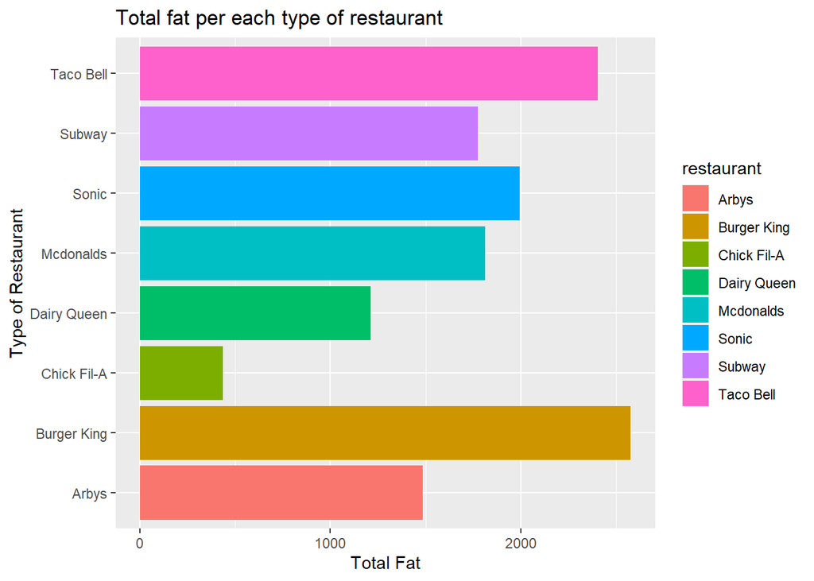

```r
Total_fat_rest %>%
  ggplot(aes(restaurant, Total_fat, fill = restaurant)) +
  geom_col() +
  coord_flip() +
  labs(x = "Type of Restaurant", y = "Total Fat", fill =
         "restaurant",title = "Total fat per each type of restaurant")
```

We use the bar graph to represent the best data visualization to help the reader to understand trends and pattern. This data visualization will help to present such information in purpose of make data driven decision.

16. Add a variable to the dataset, which calculates the sum of cholesterol and sodium and call it `cholesterol_sodium`.

Remove the variable `salad`

```r
Fast_food <- Fast_food%>%
  mutate(cholesterol,sodium, Chol_sodium = cholesterol+sodium )%>%
  subset(select = - salad)
```

17. Use observations for Mcdonalds to plot sugar variable against protein with `geom_point()`

```r
Mcdonalds<-Fast_food%>%
  filter(restaurant == 'Mcdonalds')
```

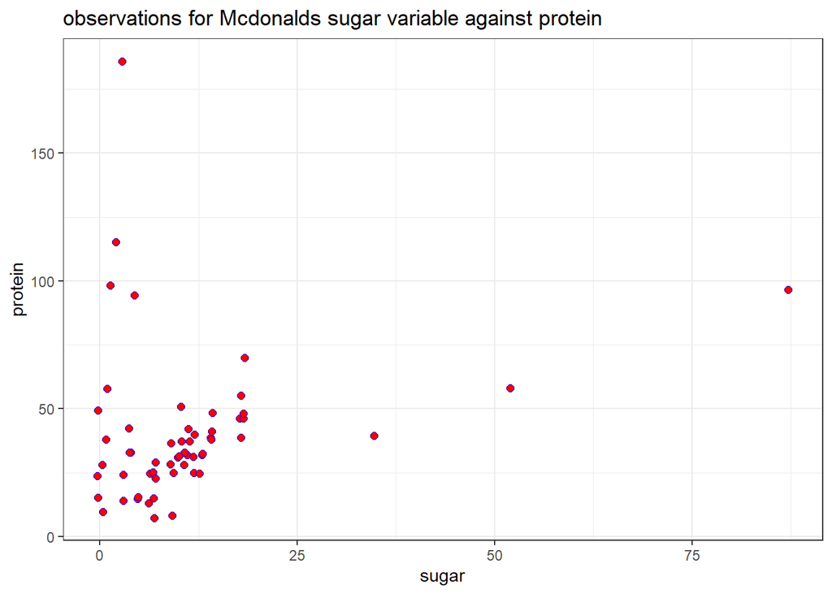

```r
Mcdonalds%>%
  ggplot(aes(sugar, protein ))+
  geom_point(position = "jitter", size = 2, shape = 21, color = "blue", fill = "red")+
  scale_fill_gradient(low = "red", high = "blue")+
  theme_bw()+
  labs(title = "observations for Mcdonalds sugar variable against protein")
```

# ASSESSMENT 1 PART 3

**Focus**: ggplot2, factors, strings, dates

18. Identify variable(s) which should be factors and transform their type into a factor variable.

from my data set summary, it showed three variable that needs to be transformed into a factor variable

1. restaurant
2. item
3. heavy_food

```r
Fast_food$restaurant<-as.factor(Fast_food$restaurant)
Fast_food$item<-as.factor(Fast_food$item)
Fast_food$heavy_food<-as.factor(Fast_food$heavy_food)
```

```r
sapply(Fast_food, class)
```

```
##           X  restaurant        item    calories     cal_fat   total_fat
##   "integer"    "factor"    "factor"   "integer"   "integer"   "integer"
##     sat_fat   trans_fat cholesterol      sodium  total_carb       fiber
##   "numeric"   "numeric"   "integer"   "integer"   "integer"   "integer"
##       sugar     protein       vit_a       vit_c     calcium  heavy_food
##   "integer"   "integer"   "integer"   "integer"   "integer"    "factor"
##     ave_cal     max_fat     min_cho Chol_sodium
##   "numeric"   "integer"   "integer"   "integer"
```

```r
summary(Fast_food)
```

```
##        X               restaurant                        item
##  Min.   :  1.0   Taco Bell  :115   Crispy Chicken Sandwich :  3
##  1st Qu.:129.5   Subway     : 96   Grilled Chicken Sandwich:  3
##  Median :258.0   Burger King: 70   Cheeseburger            :  2
##  Mean   :258.0   Mcdonalds  : 57   Chili Cheese Burrito    :  2
##  3rd Qu.:386.5   Arbys      : 55   Corn Dog                :  2
##  Max.   :515.0   Sonic      : 53   Double Cheeseburger     :  2
##                  (Other)    : 69   (Other)                 :501
##     calories         cal_fat         total_fat         sat_fat
##  Min.   :  20.0   Min.   :   0.0   Min.   :  0.00   Min.   : 0.000
##  1st Qu.: 330.0   1st Qu.: 120.0   1st Qu.: 14.00   1st Qu.: 4.000
##  Median : 490.0   Median : 210.0   Median : 23.00   Median : 7.000
##  Mean   : 530.9   Mean   : 238.8   Mean   : 26.59   Mean   : 8.153
##  3rd Qu.: 690.0   3rd Qu.: 310.0   3rd Qu.: 35.00   3rd Qu.:11.000
##  Max.   :2430.0   Max.   :1270.0   Max.   :141.00   Max.   :47.000
##
##    trans_fat      cholesterol         sodium       total_carb
##  Min.   :0.000   Min.   :  0.00   Min.   :  15   Min.   :  0.00
##  1st Qu.:0.000   1st Qu.: 35.00   1st Qu.: 800   1st Qu.: 28.50
##  Median :0.000   Median : 60.00   Median :1110   Median : 44.00
##  Mean   :0.465   Mean   : 72.46   Mean   :1247   Mean   : 45.66
##  3rd Qu.:1.000   3rd Qu.: 95.00   3rd Qu.:1550   3rd Qu.: 57.00
##  Max.   :8.000   Max.   :805.00   Max.   :6080   Max.   :156.00
##
##      fiber            sugar           protein           vit_a
##  Min.   : 0.000   Min.   : 0.000   Min.   :  1.00   Min.   :  0.00
##  1st Qu.: 2.000   1st Qu.: 3.000   1st Qu.: 16.00   1st Qu.:  4.00
##  Median : 3.000   Median : 6.000   Median : 24.50   Median : 10.00
##  Mean   : 4.137   Mean   : 7.262   Mean   : 27.89   Mean   : 18.86
##  3rd Qu.: 5.000   3rd Qu.: 9.000   3rd Qu.: 36.00   3rd Qu.: 20.00
##  Max.   :17.000   Max.   :87.000   Max.   :186.00   Max.   :180.00
##  NA's   :12                        NA's   :1        NA's   :214
##      vit_c           calcium         heavy_food     ave_cal
##  Min.   :  0.00   Min.   :  0.00   average:201   Min.   :384.4
##  1st Qu.:  4.00   1st Qu.:  8.00   heavy  :246   1st Qu.:443.7
##  Median : 10.00   Median : 20.00   low    : 68   Median :520.2
##  Mean   : 20.17   Mean   : 24.85                 Mean   :530.9
##  3rd Qu.: 30.00   3rd Qu.: 30.00                 3rd Qu.:608.6
##  Max.   :400.00   Max.   :290.00                 Max.   :640.4
##  NA's   :210      NA's   :210
##     max_fat          min_cho        Chol_sodium
##  Min.   : 42.00   Min.   : 0.000   Min.   :  15
##  1st Qu.: 47.00   1st Qu.: 0.000   1st Qu.: 850
##  Median : 62.00   Median : 0.000   Median :1180
##  Mean   : 78.84   Mean   : 3.592   Mean   :1319
##  3rd Qu.:100.00   3rd Qu.: 5.000   3rd Qu.:1662
##  Max.   :141.00   Max.   :25.000   Max.   :6555
##
```

Result for question 18 after the variable transformed

```r
summary(Fast_food)
```

```
##        X               restaurant                        item
##  Min.   :  1.0   Taco Bell  :115   Crispy Chicken Sandwich :  3
##  1st Qu.:129.5   Subway     : 96   Grilled Chicken Sandwich:  3
##  Median :258.0   Burger King: 70   Cheeseburger            :  2
##  Mean   :258.0   Mcdonalds  : 57   Chili Cheese Burrito    :  2
##  3rd Qu.:386.5   Arbys      : 55   Corn Dog                :  2
##  Max.   :515.0   Sonic      : 53   Double Cheeseburger     :  2
##                  (Other)    : 69   (Other)                 :501
##     calories         cal_fat         total_fat         sat_fat
##  Min.   :  20.0   Min.   :   0.0   Min.   :  0.00   Min.   : 0.000
##  1st Qu.: 330.0   1st Qu.: 120.0   1st Qu.: 14.00   1st Qu.: 4.000
##  Median : 490.0   Median : 210.0   Median : 23.00   Median : 7.000
##  Mean   : 530.9   Mean   : 238.8   Mean   : 26.59   Mean   : 8.153
##  3rd Qu.: 690.0   3rd Qu.: 310.0   3rd Qu.: 35.00   3rd Qu.:11.000
##  Max.   :2430.0   Max.   :1270.0   Max.   :141.00   Max.   :47.000
##
##    trans_fat      cholesterol         sodium       total_carb
##  Min.   :0.000   Min.   :  0.00   Min.   :  15   Min.   :  0.00
##  1st Qu.:0.000   1st Qu.: 35.00   1st Qu.: 800   1st Qu.: 28.50
##  Median :0.000   Median : 60.00   Median :1110   Median : 44.00
##  Mean   :0.465   Mean   : 72.46   Mean   :1247   Mean   : 45.66
##  3rd Qu.:1.000   3rd Qu.: 95.00   3rd Qu.:1550   3rd Qu.: 57.00
##  Max.   :8.000   Max.   :805.00   Max.   :6080   Max.   :156.00
##
##      fiber            sugar           protein           vit_a
##  Min.   : 0.000   Min.   : 0.000   Min.   :  1.00   Min.   :  0.00
##  1st Qu.: 2.000   1st Qu.: 3.000   1st Qu.: 16.00   1st Qu.:  4.00
##  Median : 3.000   Median : 6.000   Median : 24.50   Median : 10.00
##  Mean   : 4.137   Mean   : 7.262   Mean   : 27.89   Mean   : 18.86
##  3rd Qu.: 5.000   3rd Qu.: 9.000   3rd Qu.: 36.00   3rd Qu.: 20.00
##  Max.   :17.000   Max.   :87.000   Max.   :186.00   Max.   :180.00
##  NA's   :12                        NA's   :1        NA's   :214
##      vit_c           calcium         heavy_food     ave_cal
##  Min.   :  0.00   Min.   :  0.00   average:201   Min.   :384.4
##  1st Qu.:  4.00   1st Qu.:  8.00   heavy  :246   1st Qu.:443.7
##  Median : 10.00   Median : 20.00   low    : 68   Median :520.2
##  Mean   : 20.17   Mean   : 24.85                 Mean   :530.9
##  3rd Qu.: 30.00   3rd Qu.: 30.00                 3rd Qu.:608.6
##  Max.   :400.00   Max.   :290.00                 Max.   :640.4
##  NA's   :210      NA's   :210
##     max_fat          min_cho        Chol_sodium
##  Min.   : 42.00   Min.   : 0.000   Min.   :  15
##  1st Qu.: 47.00   1st Qu.: 0.000   1st Qu.: 850
##  Median : 62.00   Median : 0.000   Median :1180
##  Mean   : 78.84   Mean   : 3.592   Mean   :1319
##  3rd Qu.:100.00   3rd Qu.: 5.000   3rd Qu.:1662
##  Max.   :141.00   Max.   :25.000   Max.   :6555
##
```

19. Create two new variables:

Read about `cut_number()` function using Help and add a new variable to the dataset `calories_type`. Use `calories` variable for `cut_number()` function to split it into 3 categories `n=3`, add labels `labels=c("low", "med", "high")` and make the dataset ordered by arranging it according to calories.

```r
Fast_food <- Fast_food %>%
  mutate(calories_type = cut_number(calories, n=3, labels = c ("low","med","high")))
```

```r
Fast_food%>%
  arrange(calories)%>%
  head(n = 20) %>%
  kable()
```

| X | restaurant | item | calories | cal_fat | total_fat | sat_fat | trans_fat | cholesterol | sodium | total_carb | fiber | sugar | protein | vit_a | vit_c | calcium | heavy_food | ave_cal | max_fat | min_cho | Chol_sodium | calories_type |
| --- | --- | --- | --- | --- | --- | --- | --- | --- | --- | --- | --- | --- | --- | --- | --- | --- | --- | --- | --- | --- | --- | --- |
| 303 | Dairy Queen | Side Salad | 20 | 0 | 0 | 0.0 | 0.0 | 0 | 15 | 5 | 2 | 3 | 1 | 50 | 30 | 15 | low | 520.2381 | 75 | 0 | 15 | low |
| 393 | Subway | Veggie Delite Salad | 50 | 10 | 1 | 0.0 | 0.0 | 0 | 65 | 9 | 4 | 4 | 3 | 25 | 45 | 4 | low | 503.0208 | 62 | 0 | 65 | low |
| 73 | Chick Fil-A | 4 Piece Grilled Chicken Nuggets | 70 | 18 | 2 | 1.0 | 0.0 | 35 | 220 | 1 | 0 | 0 | 13 | 0 | 6 | 0 | low | 384.4444 | 47 | 25 | 255 | low |
| 188 | Arbys | Chopped Side Salad | 70 | 45 | 5 | 2.5 | 0.0 | 15 | 100 | 4 | 1 | 2 | 5 | 35 | 10 | 10 | low | 532.7273 | 59 | 15 | 115 | low |
| 128 | Sonic | Ultimate Chicken Club | 100 | 580 | 64 | 15.0 | 0.5 | 100 | 2070 | 65 | 4 | 12 | 39 | 15 | 8 | 30 | low | 631.6981 | 100 | 0 | 2170 | low |
| 74 | Chick Fil-A | 6 Piece Grilled Chicken Nuggets | 110 | 27 | 3 | 1.0 | 0.0 | 50 | 330 | 2 | 0 | 0 | 19 | 0 | 8 | 0 | low | 384.4444 | 47 | 25 | 380 | low |
| 373 | Subway | Black Forest Ham Salad | 110 | 25 | 3 | 1.0 | 0.0 | 20 | 590 | 11 | 4 | 6 | 12 | 25 | 45 | 4 | low | 503.0208 | 62 | 0 | 610 | low |
| 391 | Subway | Turkey Breast & Ham Salad | 110 | 20 | 3 | 1.0 | 0.0 | 25 | 580 | 11 | 4 | 5 | 12 | 25 | 45 | 6 | low | 503.0208 | 62 | 0 | 605 | low |
| 392 | Subway | Turkey Breast Salad | 110 | 20 | 2 | 1.0 | 0.0 | 20 | 570 | 11 | 4 | 5 | 12 | 25 | 45 | 6 | low | 503.0208 | 62 | 0 | 590 | low |
| 61 | Chick Fil-A | 1 Piece Chick-n-Strips | 120 | 54 | 6 | 3.0 | 0.0 | 25 | 320 | 6 | 0 | 1 | 11 | 0 | 0 | 2 | low | 384.4444 | 47 | 25 | 345 | low |
| 66 | Chick Fil-A | 4 piece Chicken Nuggets | 130 | 54 | 6 | 1.5 | 0.0 | 40 | 490 | 5 | 1 | 0 | 14 | 0 | 2 | 2 | low | 384.4444 | 47 | 25 | 530 | low |
| 49 | Mcdonalds | Premium Asian Salad w/o Chicken | 140 | 70 | 7 | 0.5 | 0.0 | 0 | 20 | 13 | 5 | 7 | 7 | 180 | 45 | 10 | low | 640.3509 | 141 | 0 | 20 | low |
| 75 | Chick Fil-A | 8 piece Grilled Chicken Nuggets | 140 | 36 | 4 | 1.0 | 0.0 | 70 | 440 | 2 | 0 | 0 | 25 | 0 | 10 | 2 | low | 384.4444 | 47 | 25 | 510 | low |
| 383 | Subway | Oven Roasted Chicken Salad | 140 | 25 | 3 | 0.5 | 0.0 | 50 | 280 | 10 | 4 | 4 | 19 | 50 | 60 | 8 | low | 503.0208 | 62 | 0 | 330 | low |
| 384 | Subway | Roast Beef Salad | 140 | 30 | 4 | 1.0 | 0.0 | 40 | 450 | 10 | 4 | 5 | 18 | 25 | 45 | 4 | low | 503.0208 | 62 | 0 | 490 | low |
| 387 | Subway | Subway Club Salad | 140 | 30 | 4 | 1.0 | 0.0 | 40 | 640 | 11 | 4 | 5 | 17 | 25 | 45 | 6 | low | 503.0208 | 62 | 0 | 680 | low |
| 466 | Taco Bell | Fresco Crunchy Taco | 140 | 70 | 8 | 2.0 | 0.0 | 20 | 290 | 13 | 3 | 1 | 6 | NA | NA | NA | low | 443.6522 | 42 | 0 | 310 | low |
| 300 | Dairy Queen | Grilled Chicken Garden Greens Salad | 150 | 20 | 2 | 0.5 | 0.0 | 40 | 730 | 10 | 3 | 6 | 23 | NA | NA | NA | low | 520.2381 | 75 | 0 | 770 | low |
| 364 | Subway | Kids Mini Sub Veggie Delite | 150 | 15 | 2 | 0.0 | 0.0 | 0 | 190 | 29 | 3 | 4 | 6 | 6 | 15 | 20 | low | 503.0208 | 62 | 0 | 190 | low |
| 370 | Subway | B.L.T. Salad | 150 | 70 | 8 | 4.0 | 0.0 | 20 | 420 | 10 | 4 | 5 | 10 | 50 | 50 | 6 | low | 503.0208 | 62 | 0 | 440 | low |

Do not forget to save the updated dataset.

20. Create a dataviz that shows the distribution of `calories_type` in food items for each type of restaurant. Think carefully about the choice of data viz. Use facets, coordinates and theme layers to make your data viz visually appealing and meaningful. Use factors related data viz functions.

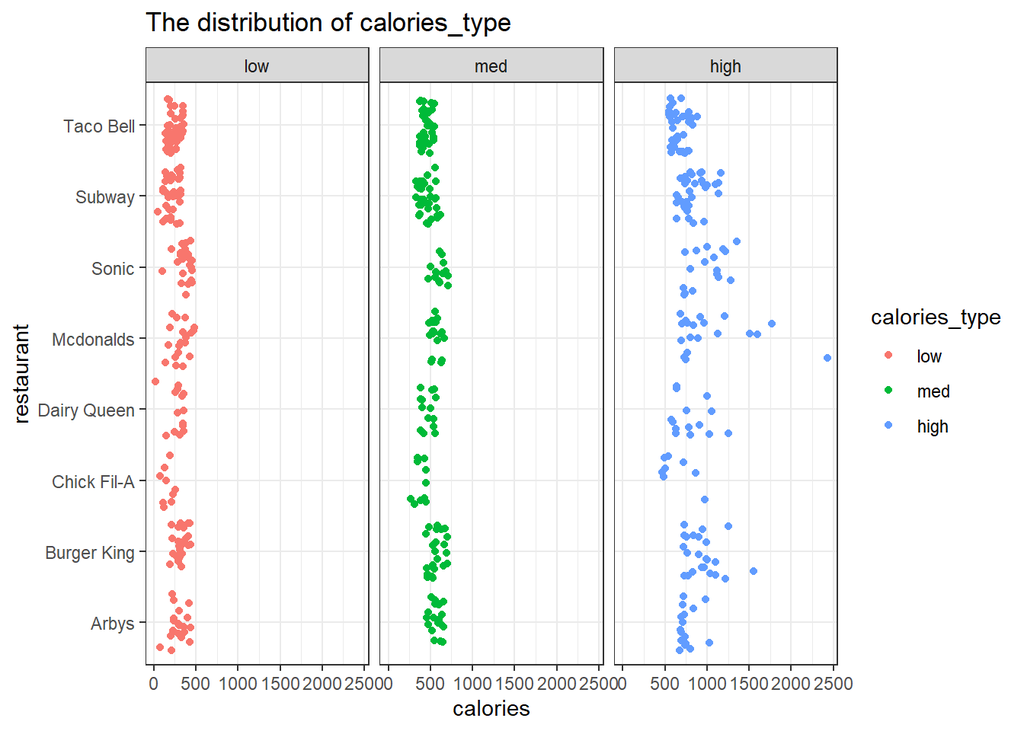

```r
Fast_food %>%
  ggplot(aes(calories, restaurant, colour = calories_type))+
  geom_jitter()+
  facet_wrap(~calories_type)+
  theme_bw()+
  labs(title = "The distribution of calories_type")
```

21. The second variable should show the percentage of `trans_fat` in `total_fat`. Add the variable to the dataset and call it `trans_fat_percent`. Do not forget to save the updated dataset.

```r
Fast_food <- Fast_food%>%
  mutate(trans_fat_percent = (trans_fat/total_fat)*100)
```

22. Create a dataviz that shows the distribution of `trans_fat` in food items for each type of restaurant. Think carefully about the choice of data viz. Use facets, coordinates and theme layers to make your data viz visually appealing and meaningful.

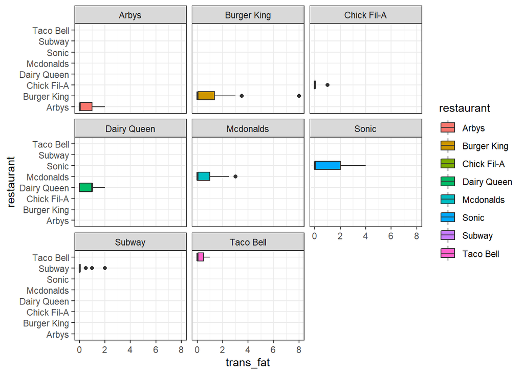

```r
Fast_food%>%
  ggplot(aes(restaurant, trans_fat, fill = restaurant ))+
  coord_flip()+
  geom_boxplot()+
  facet_wrap(~restaurant)+
  theme_bw()
```

23. Calculate and show the average (mean) `total_fat` for each type of restaurant. No need to save it as a variable.

```r
Fast_food%>%
  group_by(restaurant)%>%
  summarise(mean_total_fat=mean(total_fat))
```

```
## # A tibble: 8 x 2
##   restaurant  mean_total_fat
##   <fct>                <dbl>
## 1 Arbys                 27.0
## 2 Burger King           36.8
## 3 Chick Fil-A           16.1
## 4 Dairy Queen           28.9
## 5 Mcdonalds             31.8
## 6 Sonic                 37.6
## 7 Subway                18.5
## 8 Taco Bell             20.9
```

24. And create a dataviz that allow to compare different restaurants on this variable (`total_fat`). You can present it on one dataviz (= no facets).

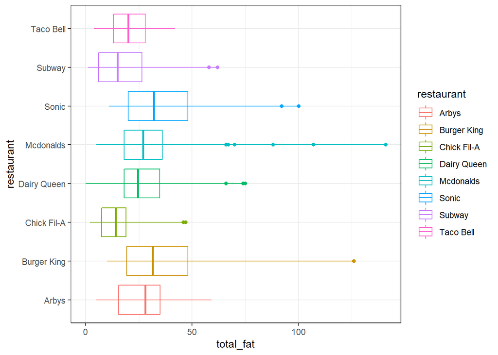

```r
Fast_food%>%
  ggplot(aes(restaurant,total_fat, color = restaurant))+
  coord_flip()+
  geom_boxplot()+
  geom_line()+
  theme_bw()
```

Think carefully about the choice of data viz. Use coordinates and theme layers to make your data viz visually appealing and meaningful.